# 11.2 Exercise

## Fit a k nearest neighbors’ model for each dataset for k=3, k=5, k=10, k=15, k=20, and k=25. Compute the accuracy of the resulting models for each value of k. Plot the results in a graph where the x-axis is the different values of k and the y-axis is the accuracy of the model.

## Fitting a model is when you use the input data to create a predictive model. There are various metrics you can use to determine how well your model fits the data. For this problem, you will focus on a single metric, accuracy. Accuracy is simply the percentage of how often the model predicts the correct result. If the model always predicts the correct result, it is 100% accurate. If the model always predicts the incorrect result, it is 0% accurate.

```r
# Create a K nearest list the k nearest neighbors for binary data.
k_nearest <- list(3,5,10,15,20,25)
input=1
binary_accuracy=1
for (input in k_nearest) {
  nearest_neighbor <- knn(train = binary_train, test = binary_test, cl=train_label_binary, k=input)
  binary_accuracy[input] <- 100*sum(test_label_binary == nearest_neighbor)/NROW(test_label_binary)
  k=input
  cat(k,'=',binary_accuracy[input],'')
}
```

```
## 3 = 98.16667 5 = 97.66667 10 = 97.5 15 = 97.16667 20 = 97.5 25 = 97.33333
```

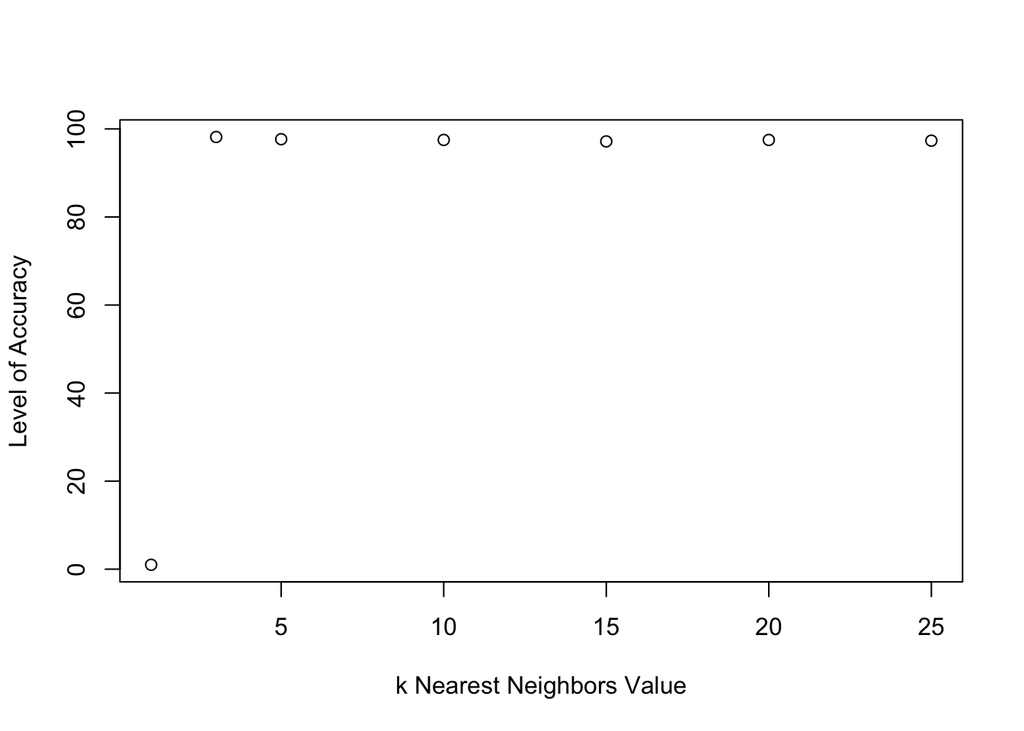

```r
# Next I will plot the accuracy of my k values for binary
plot(binary_accuracy, type = "b", xlab = "k Nearest Neighbors Value", ylab = "Level of Accuracy")
```

```r
# Create a K nearest list the k nearest neighbors for trinary data.
k_nearest_trinary <- list(3,5,10,15,20,25)
input_trinary=1
trinary_accuracy=1
for (input_trinary in k_nearest_trinary) {
  trinary_nearest <- knn(train = trinary_train, test = trinary_test, cl=train_label_trinary, k=input_trinary)
  trinary_accuracy[input_trinary] <- 100*sum(test_label_trinary == trinary_nearest)/NROW(test_label_trinary)
  k=input_trinary
  cat(k,'=',trinary_accuracy[input_trinary])
}
```

```
## 3 = 92.197455 = 91.082810 = 89.3312115 = 88.375820 = 86.7834425 = 87.73885
```

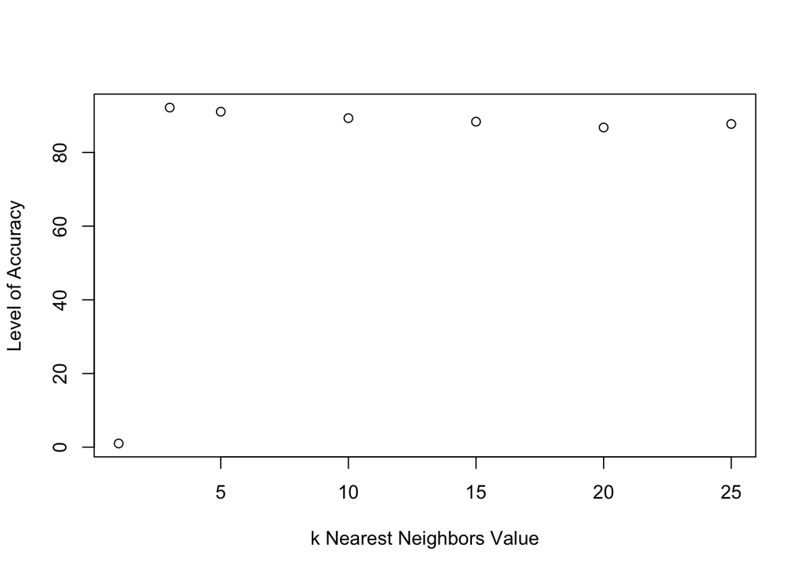

```r
# Next I will plot the accuracy of my k values for binary
plot(trinary_accuracy, type = "b", xlab = "k Nearest Neighbors Value", ylab = "Level of Accuracy")
```

## Looking back at the plots of the data, do you think a linear classifier would work well on these datasets?